# Nonmetric Multidimensional Scaling (NMDS) Example

Matthew W. Van Scoyoc

Thursday, January 15, 2015

# R Markdown Intro

(Default text when you start a markdown document in RStudio)  
This is an R Markdown document. Markdown is a simple formatting syntax for authoring HTML, PDF, and MS Word documents. For more details on using R Markdown see http://rmarkdown.rstudio.com.

# R Markdown Tips

- To start an R Markdown document select “R Markdown” from the options in the “New Document” dropdown.
- Text in the white area is normal text in the final document.
- R code is written in “chunks” (the grey areas) or in-line using “wirte code here”.
- Click on the “?” dropdown button to access markdown references. I use the “Markdown Quick Reference” in the help panel a lot.
- There are a lot of chunk options, check out to http://yihui.name/knitr/options/ when you are looking for something specific.
- For more information on R Markdown go to http://rmarkdown.rstudio.com/. To start with, check out the “Home” page, “..Authoring/Markdown Basics” and “…Authoring/R Code Chunks”.

# NMDS Example

In this example will use the ‘varespec’ and ‘varechem’ data sets in the vegan package to run an NMDS and cluster analysis to examine lichen species communities. We will also be using the source file ‘biostats.R’ developed by Kevin McGarigal at the University of Massachusetts. This source file has a lot of good functions for analyzing ecological data.  
(Note that the three lines above this one did not break to a new line in the document.  
You need to add 2 spaces at the end of a line if you want the next line to be a new line in the document.)

```r
> # ----- Nonmetric Multidimensionsl Scaling (NMDS) ----- Run an NMDS using
> # Bray-Curtis dissimilarity with 2 dimensions on the species data.
> sp.nmds = metaMDS(varespec, distance = "bray", k = 2, autotransform = FALSE,
+     trymax = 100, zerodist = "add")
```

```
## ... procrustes: rmse 1.982038e-05  max resid 5.457578e-05
## *** Solution reached
```

```r
> sp.nmds
```

```
##
## Call:
## metaMDS(comm = varespec, distance = "bray", k = 2, trymax = 100,      autotransform = FALSE, zerodist = "add")
##
## global Multidimensional Scaling using monoMDS
##
## Data:     varespec
## Distance: bray
##
## Dimensions: 2
## Stress:     0.1000211
## Stress type 1, weak ties
## Two convergent solutions found after 1 tries
## Scaling: centring, PC rotation, halfchange scaling
## Species: expanded scores based on 'varespec'
```

Very good NMDS. Two dimensions gave us a stress of 0.1.

## Vector fitting

Now we’ll fit the species and soil vectors to the NMDS and print the results.

```
##
## ***VECTORS
##
##             NMDS1    NMDS2     r2    Pr(>r)
## Callvulg -0.32381 -0.94612 0.0919 0.3904610
## Empenigr  0.21354  0.97694 0.1986 0.0972903 .
## Rhodtome  0.56694  0.82376 0.2347 0.0498950 *
## Vaccmyrt  0.77288  0.63456 0.4282 0.0007999 ***
## Vaccviti  0.36221  0.93210 0.3613 0.0084992 **
## Pinusylv -0.27690  0.96090 0.1139 0.2872713
## Descflex  0.85261  0.52255 0.1636 0.1273873
## Betupube  0.27383  0.96178 0.1542 0.1550845
## Vacculig -0.36456 -0.93118 0.1077 0.3275672
## Diphcomp -0.89962 -0.43668 0.0371 0.7428257
## Dicrsp    0.98713 -0.15991 0.1719 0.1206879
## Dicrfusc  0.64950 -0.76036 0.3171 0.0098990 **
## Dicrpoly  0.42281  0.90622 0.2083 0.0711929 .
## Hylosple  0.90152  0.43274 0.3296 0.0034997 **
## Pleuschr  0.99573  0.09231 0.7412 9.999e-05 ***
## Polypili -0.63944 -0.76884 0.0957 0.3643636
## Polyjuni  0.92870 -0.37083 0.0875 0.4192581
## Polycomm  0.58500  0.81103 0.2078 0.0862914 .
## Pohlnuta  0.18969  0.98184 0.2692 0.0377962 *
## Ptilcili  0.20948  0.97781 0.1696 0.1224878
## Barbhatc  0.19182  0.98143 0.1607 0.1220878
## Cladarbu -0.44356 -0.89625 0.6472 9.999e-05 ***
## Cladrang -0.81495 -0.57953 0.6835 9.999e-05 ***
## Cladstel -0.54675  0.83730 0.7697 9.999e-05 ***
## Cladunci  0.35088 -0.93642 0.2236 0.0450955 *
## Cladcocc -0.65150 -0.75865 0.2161 0.0789921 .
## Cladcorn  0.83550 -0.54949 0.0273 0.7828217
## Cladgrac  0.41563 -0.90953 0.0435 0.6242376
## Cladfimb -0.98133 -0.19232 0.0099 0.8967103
## Cladcris  0.45106 -0.89249 0.0515 0.5949405
## Cladchlo -0.17601  0.98439 0.4054 0.0032997 **
## Cladbotr  0.32068  0.94719 0.1567 0.1521848
## Cladamau -0.77294 -0.63448 0.0965 0.3636636
## Cladsp   -0.51873  0.85494 0.1120 0.2958704
## Cetreric  0.06909 -0.99761 0.0948 0.3567643
## Cetrisla -0.03574  0.99936 0.3713 0.0030997 **
## Flavniva -0.99950  0.03151 0.0963 0.3484652
## Nepharct  0.89517 -0.44573 0.0762 0.5207479
## Stersp   -0.54107 -0.84098 0.2604 0.0071993 **
## Peltapht  0.91546  0.40242 0.0152 0.8572143
## Icmaeric -0.28607 -0.95821 0.3377 0.0052995 **
## Cladcerv -0.94165  0.33659 0.0772 0.4457554
## Claddefo  0.53178 -0.84688 0.1415 0.2001800
## Cladphyl -0.42344  0.90593 0.2136 0.0817918 .
## ---
## Signif. codes:  0 '***' 0.001 '**' 0.01 '*' 0.05 '.' 0.1 ' ' 1
## Permutation: free
## Number of permutations: 10000
```

```
##
## ***VECTORS
##
##             NMDS1    NMDS2     r2   Pr(>r)
## N         0.01864 -0.99983 0.1885 0.096903 .
## P         0.66079  0.75057 0.2898 0.021978 *
## K         0.85359  0.52095 0.1830 0.103896
## Ca        0.83360  0.55237 0.3534 0.013986 *
## Mg        0.84819  0.52970 0.2901 0.022977 *
## S         0.41309  0.91069 0.0884 0.392607
## Al       -0.98934  0.14562 0.4888 0.001998 **
## Fe       -0.99349  0.11391 0.4081 0.003996 **
## Mn        0.99234  0.12355 0.4292 0.004995 **
## Zn        0.92743  0.37399 0.1650 0.126873
## Mo       -0.85992 -0.51042 0.0476 0.588412
## Baresoil  0.91934 -0.39347 0.1877 0.126873
## Humdepth  0.98856  0.15082 0.4415 0.005994 **
## pH       -0.86063  0.50924 0.2252 0.067932 .
## ---
## Signif. codes:  0 '***' 0.001 '**' 0.01 '*' 0.05 '.' 0.1 ' ' 1
## Permutation: free
## Number of permutations: 1000
```

# Visualize the NMDS

## Diagnostic Figures

Here we’ll examine the ordered observations next the NMDS illustrating 1) the goodness of fit for each observation (site) and 2) the location each species plays in the ordination. This is a bit messy, but it’s a good diagnostic figure.

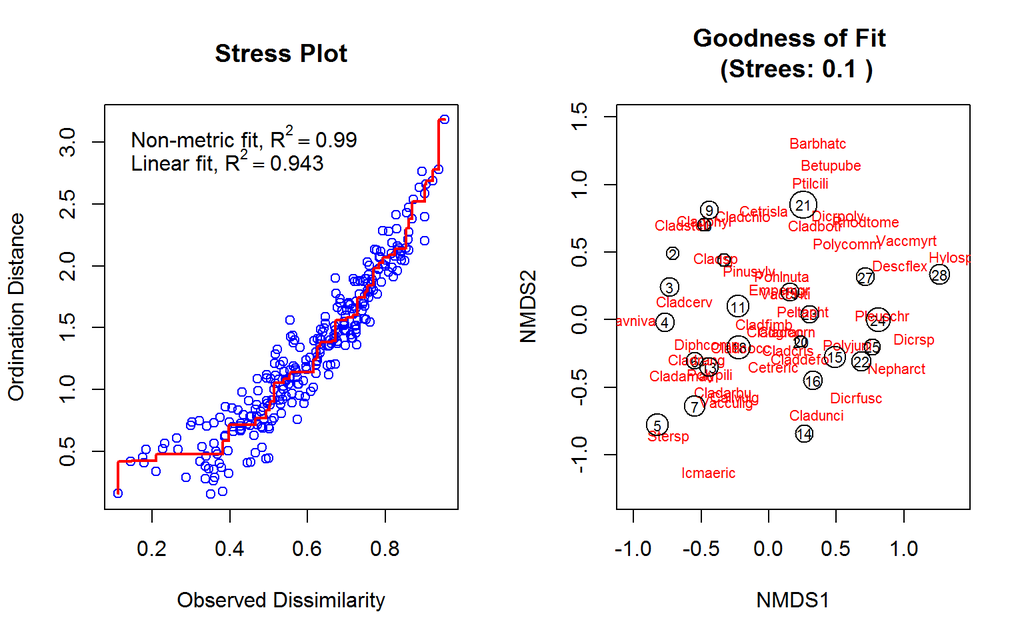

## Interpret the Axes

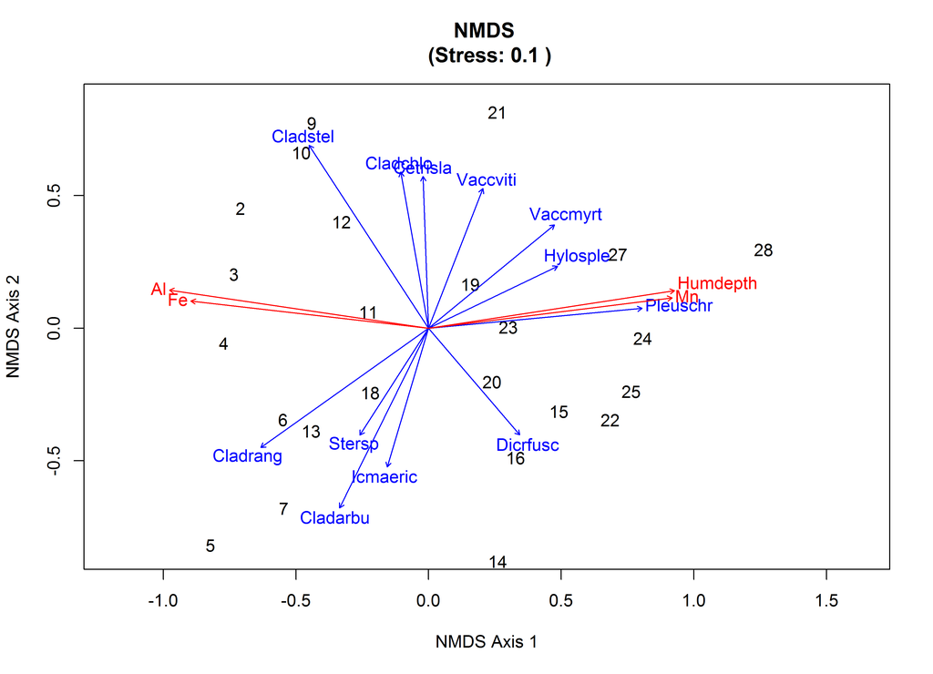

# Cluster Analysis

Wards hierarchical cluster analysis using Bray-Curtis dissimilarity identifying 4 groups

```
## sp.grps
##    1    2    3    4 <NA>
##    8    9    3    4    0
```

# Plot groups with NMDS (base R code)

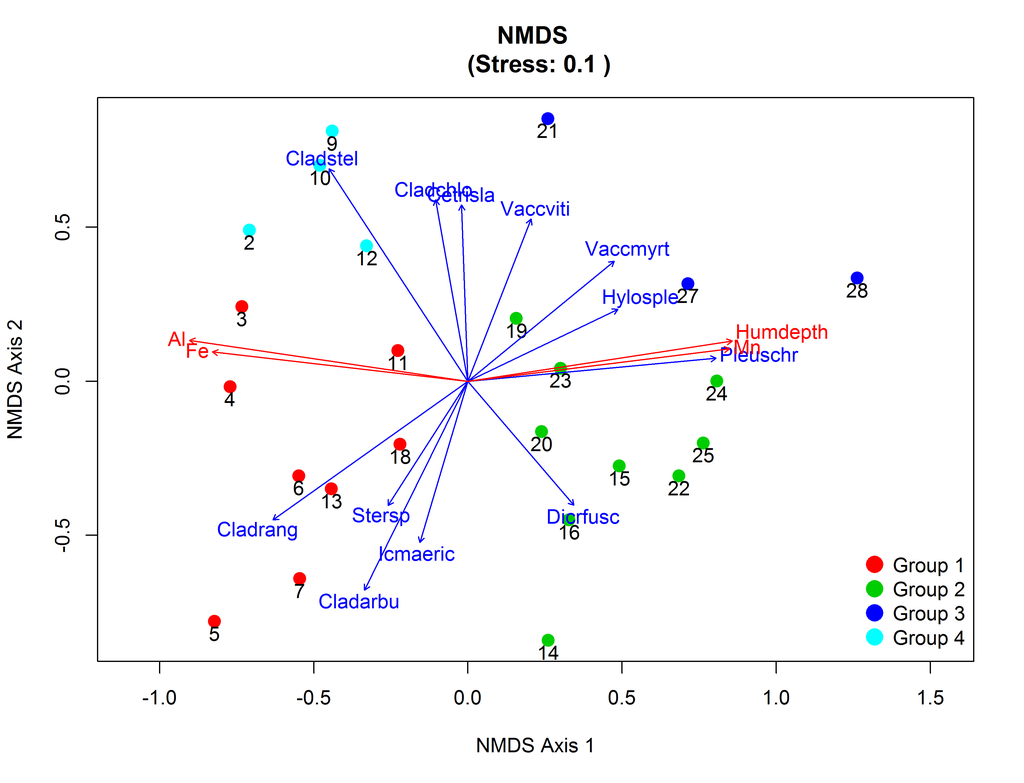

# ggplot2 Figure

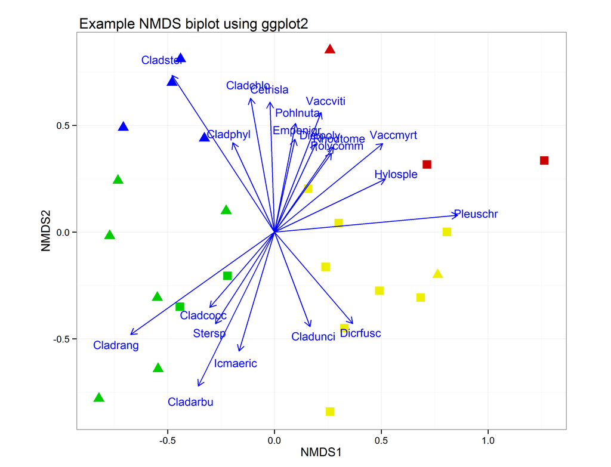

Here’s a nice table using the kable function in knitr.

|  | 1 | 2 | 3 | 4 |
| --- | --- | --- | --- | --- |
| A | 2 | 8 | 2 | 0 |
| B | 6 | 1 | 1 | 4 |

# References:

Borcard, D., Gillet, F. & Legendre, P. (2011) Numerical Ecology with R. Chapter 5.  
R_document_8_NMDS.pdf  
vegantutor.pdf

All analyses were performed using R (ver. 3.1.2; R Core Team 2014) and the packages vegan (ver. 2.2-1; Oksanen et al. 2014) and cluster (ver. 1.15.3; Maechler et al. 2014) for statistical analysis. The ggplot2 package (ver. 1.0.0; Wickham 2009) was used to produce figures, and knitr (ver 1.8; Xie 2014) was used for reproducible research.

This report was automatically generated with R Markdown v2. The R session information (including the OS info, R version, and all packages used):

[session information not shown]

```
## [1] "2015-01-27 14:00:23 MST"
```